# MCU Box Office Analysis

## Part 3 - Box office of Endgame by country

$$\\[0.2in]$$

In part 3, we will examine the box office returns of the highest grossing MCU film “Avengers: Endgame” (2019) as it relates to the countries it was released in. The data we use here is available on boxofficemojo.com and contains the film’s release date, the market (i.e. the country it was released in), the earning over the opening weekend the gross earnings at the box office.

Firstly, the data is collected and cleaned.

```r
# Scrape multiple tables

library(rvest)

url <- "https://www.box officemojo.com/releasegroup/gr3511898629/"

endgame <- url %>%
  read_html() %>%
  html_nodes("table") %>%
  html_table(fill = TRUE)


# Convert list of dataframes into a single dataframe

endgame <- bind_rows(endgame)


endgame[3:nrow(endgame), 1:16] <- endgame[3:nrow(endgame), 5:ncol(endgame)]

endgame[36:nrow(endgame), 1:16] <- endgame[36:nrow(endgame), 5:ncol(endgame)]

endgame[46:nrow(endgame), 1:16] <- endgame[46:nrow(endgame), 5:ncol(endgame)]

endgame[61:nrow(endgame), 1:16] <- endgame[61:nrow(endgame), 5:ncol(endgame)]

endgame[,5:ncol(endgame)] <- NULL


# Rename column names

names(endgame) <- c('Market', 'Release Date', 'Opening', 'Gross')


# Clean up dataframe

endgame <- endgame %>%
  filter(!Market %in% c("Market")
         & !`Release Date` %in% c("Release Date"))     # Note: `` allows indexing column with a space in name


# Convert box office to numeric

endgame$Gross <- as.numeric(gsub('[$,]', '', endgame$Gross))
endgame$Opening <- as.numeric(gsub('[$,]', '', endgame$Opening))


# Change some country names to match with map data

library(sf)
library("rnaturalearth")
library("rnaturalearthdata")

world <- ne_countries(scale = "medium", returnclass = "sf")

endgame$Market[which(!(endgame$Market %in% world$name))]

endgame$Market[1] <- "United States"
endgame$Market[6] <- "Czech Rep."
endgame$Market[23] <- "Serbia"
endgame$Market[30] <- "Turkey"
endgame$Market[51] <- "Russia"
endgame$Market[53] <- "Korea"


# Add regions

library(countrycode)

endgame$Region <- countrycode(sourcevar = as.factor(endgame$Market), origin = "country.name", destination = "region")


# Rename United States to include Canada

endgame$Market[1] <- "United States & Canada"


# Remove release date from data frame

endgame <- endgame %>%
  select(-"Release Date")
```

Save and observe data

```r
# Save endgame
#saveRDS(endgame, file = "endgame.rds")

endgame <- readRDS(file = "endgame.rds")

endgame
```

| Market | Opening | Gross | Region |
| --- | --- | --- | --- |
| United States & Canada | 357115007 | 858373000 | North America |
| Austria | 3563042 | 8381072 | Europe & Central Asia |
| Belgium | 3141578 | 8682740 | Europe & Central Asia |
| Bulgaria | 442037 | 128072 | Europe & Central Asia |
| Croatia | 545732 | 1144369 | Europe & Central Asia |
| Czech Rep. | 2534713 | 6610971 | Europe & Central Asia |
| Denmark | 4223121 | 10254418 | Europe & Central Asia |
| Egypt | NA | 1754341 | Middle East & North Africa |
| Finland | 2137080 | 4942382 | Europe & Central Asia |
| France | 24971474 | 62191621 | Europe & Central Asia |

[output cut: 47 more lines]

$$\\[0.5in]$$

We will take an initial look at the gross earnings over various regions.

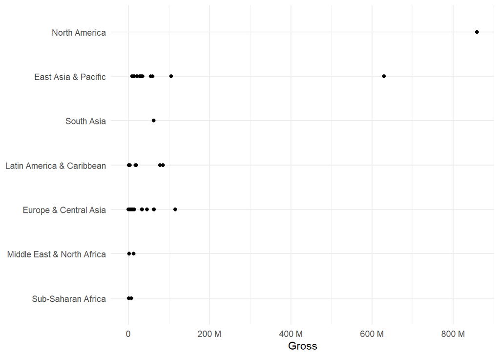

```r
ggplot(endgame, aes(x = reorder(Region, Gross), y = Gross))+
  geom_point()+
  theme(axis.text.x = element_text(angle = 90, vjust = 0.5, hjust=1))+
  labs(x = NULL)+
  coord_flip()+
  scale_y_continuous(labels = unit_format(unit = "M", scale = 1e-8, accuracy = 0.5))+
  scale_y_continuous(breaks = seq(0, 1000000000, by = 200000000),
                     labels = c(0,"200 M", "400 M", "600 M", "800 M", "1 B"))+
  theme_minimal()
```

$$\\[0.2in]$$

Clearly the regions “North America” and “East Asia & Pacific” account for a large amount of the earnings. “North America” only has one data point as the box office of Canada is included in the domestic box office for North America. In the case of East Asia, we observe an outlier bringing in over $600 million, considerably more than the other countries in the region. The Middle East, North Africa and Sub-Saharan Africa appear to have generated the least money for the film.

$$\\[0.5in]$$

Let’s examine which specific countries have taken in the most money for the film. For example, the top 20 earners.

```r
#Top 20 box offices

# Create magma colour palette

mag_pal <- viridis(n = 7)

cols <- c("North America" = mag_pal[1], "East Asia & Pacific" = mag_pal[2], "Europe & Central Asia" = mag_pal[3], "Latin America & Caribbean" = mag_pal[4], "South Asia" = mag_pal[5], "Middle East & North Africa" = mag_pal[6], "Sub-Saharan Africa" = mag_pal[7])


# Select top 20 performing countries

endgame_1 <- arrange(endgame, -Gross)[1:20,]

endgame_1
```

| Market | Opening | Gross | Region |
| --- | --- | --- | --- |
| United States & Canada | 357115007 | 858373000 | North America |
| China | 175961330 | 629100298 | East Asia & Pacific |
| United Kingdom | 55981204 | 115000524 | Europe & Central Asia |
| Korea | NA | 105483265 | East Asia & Pacific |
| Brazil | 26363627 | 85672282 | Latin America & Caribbean |
| Mexico | 31905293 | 77594943 | Latin America & Caribbean |
| Germany | 27108549 | 63290219 | Europe & Central Asia |
| India | 26757337 | 62678476 | South Asia |
| France | 24971474 | 62191621 | Europe & Central Asia |
| Australia | 24010504 | 59113013 | East Asia & Pacific |

[output cut: 10 more lines]

$$\\[0.2in]$$

```r
# % of US and China together

(sum(endgame_1$Gross[1:2])/sum(endgame_1$Gross)) * 100
```

```
## [1] 60.43429
```

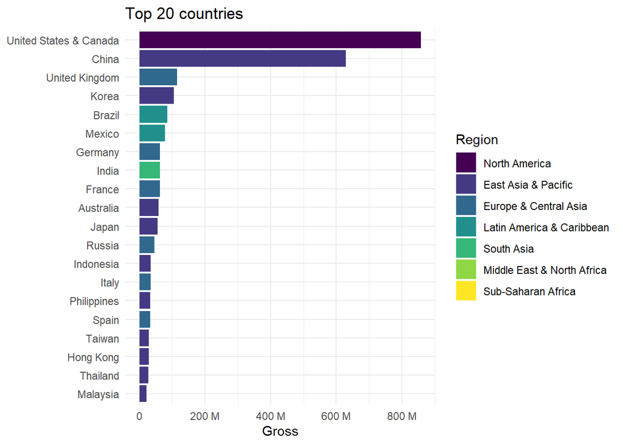

```r
ggplot(endgame_1, aes(x = reorder(Market, Gross), y = Gross, fill = Region))+
  geom_col()+
  theme(axis.text.x = element_text(angle = 90, vjust = 0.5, hjust=1))+
  scale_y_continuous(labels = unit_format(unit = "M", scale = 1e-8, accuracy = 0.5))+
  scale_y_continuous(breaks = seq(0, 1000000000, by = 200000000),
                     labels = c(0,"200 M", "400 M", "600 M", "800 M", "1 B"))+
  scale_fill_manual(values = cols)+
  theme_minimal()+
  labs(x = NULL)+
  coord_flip()+
  ggtitle("Top 20 countries")
```

$$\\[0.5in]$$

They are followed by the UK ($115 million), Korea($105 million) and Brazil ($85 million).

Countires in the regions of “Middle east & North Africa” and “Sub-Saharan Africa” are not included in the list of top 20 earners.

$$\\[0.5in]$$

When we divide the Gross earnings by region we observe that East Asia and the pacific take in the most money, followed by North America as expected.

```r
# Group data by region

endgame_3 <- endgame %>%
  group_by(Region) %>%
  summarise(Gross = sum(Gross)) %>%
  arrange(-Gross)

# Observe data

endgame_3
```

| Region | Gross |
| --- | --- |
| East Asia & Pacific | 1059308167 |
| North America | 858373000 |
| Europe & Central Asia | 482801119 |
| Latin America & Caribbean | 225101295 |
| South Asia | 62678476 |
| Middle East & North Africa | 14537530 |
| Sub-Saharan Africa | 8528064 |

$$\\[0.5in]$$

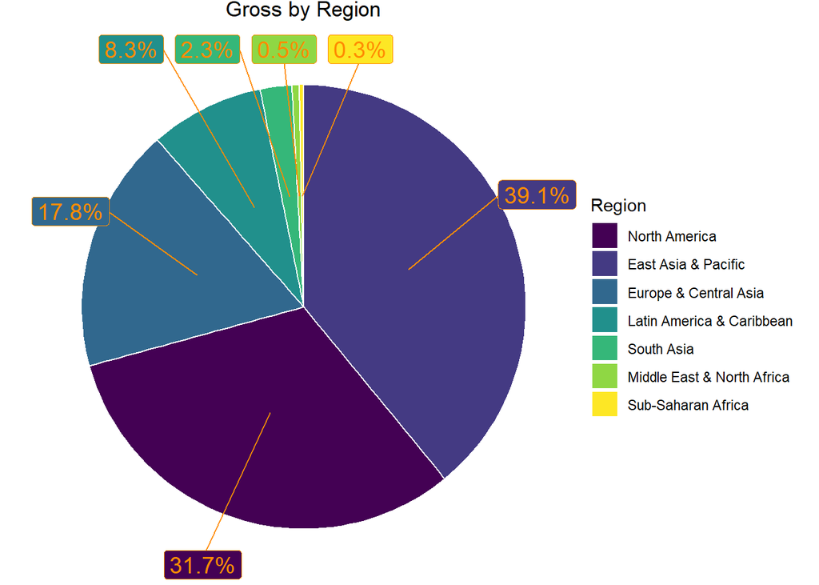

```r
# Visualise this data

# Calculate polar coordinates for piechart labels

df <- endgame_3 %>%
  arrange(Gross) %>%
  mutate(csum = rev(cumsum(rev(Gross))),
         pos = Gross/2 + lead(csum, 1),
         pos = if_else(is.na(pos), Gross/2, pos))


# Create plot

ggplot(endgame_3, aes(x="", y = Gross, fill = reorder(Region, Gross))) + #Reorder - piechart goes from highest value to lowest clockwise
  geom_bar(stat="identity", width = 1, color = "white")+
  ggtitle("Gross by Region")+
  coord_polar("y", start=0) +
  geom_label_repel(data = df,
                   aes(y = pos, label = paste0(round(Gross / sum(Gross) * 100, 1), "%")),
                   size = 5, nudge_x = 1, show.legend = FALSE, color = "darkorange") +
  scale_fill_manual(values = cols)+
  theme_void()+
  theme(plot.title = element_text(hjust = 0.5, vjust = 3)) +
  guides(fill = guide_legend(title = "Region"))
```

$$\\[0.5in]$$

Taking a closer look at East Asia and the Pacific, unsurprisingly it seems that it is China that accounts for the majority of box office earnings.

```r
endgame_Asia <- endgame %>%
                filter(Region == "East Asia & Pacific")%>%
                arrange(-Gross) %>%
                select(Market, Gross)

endgame_Asia
```

| Market | Gross |
| --- | --- |
| China | 629100298 |
| Korea | 105483265 |
| Australia | 59113013 |
| Japan | 55304132 |
| Indonesia | 34775278 |
| Philippines | 32839486 |
| Taiwan | 29386075 |
| Hong Kong | 29330722 |
| Thailand | 27230829 |
| Malaysia | 21123193 |

[output cut: 3 more lines]

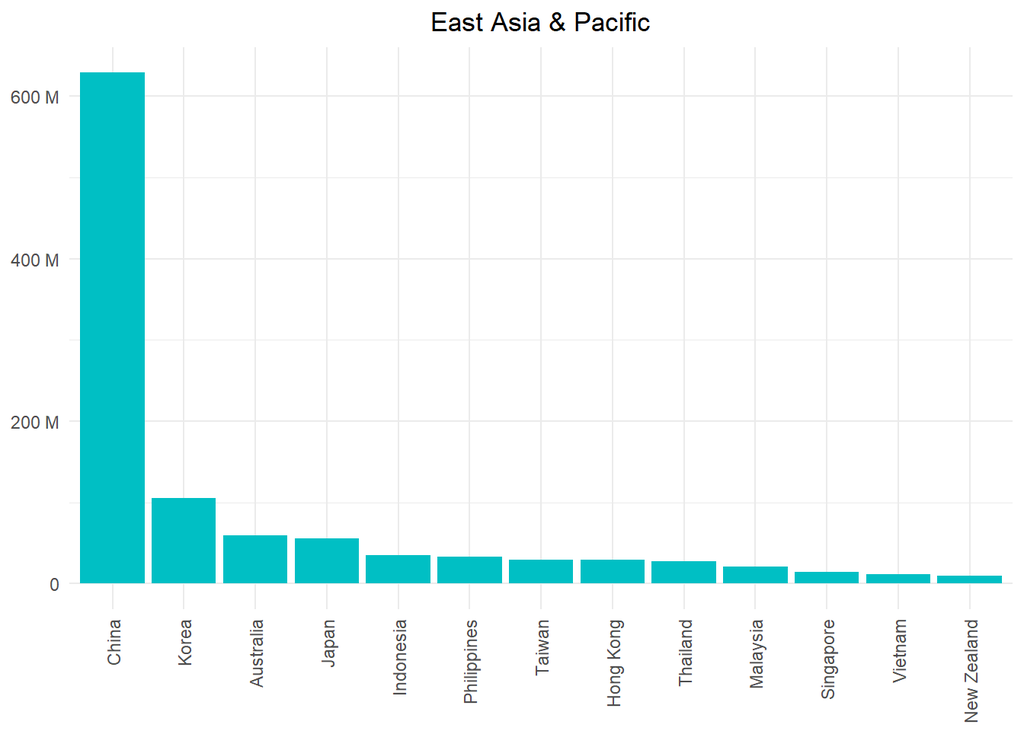

```r
ggplot(endgame_Asia, aes(reorder(Market, -Gross), Gross))+
  geom_bar(stat = "identity")+
  geom_col(fill = "#00BFC4")+
  theme_minimal()+
  theme(plot.title = element_text(hjust = 0.5),
        axis.text.x = element_text(angle = 90, vjust = 0.5, hjust=1),
        axis.title.y = element_blank(),
        axis.title.x = element_blank())+
  scale_y_continuous(labels = unit_format(unit = "M", scale = 1e-8, accuracy = 0.5))+
  scale_y_continuous(breaks = seq(0, 1000000000, by = 200000000),
                     labels = c(0,"200 M", "400 M", "600 M", "800 M", "1 B"))+
  ggtitle("East Asia & Pacific")
```

$$\\[0.5in]$$

To get a better sense of the geographical data available to us, we can visualise the endgame dataset on a world map. Here countries with available data are highlighted. Once again, note that the Canadian box office is contained in the domestic box office for North America.

```r
# Generate simple feature collection for visualisation

library("sf")
library("rnaturalearth")
library("rnaturalearthdata")

world <- ne_countries(scale = "medium", returnclass = "sf")

# Combine geometry of Canada and USA to create "North America"

North_America <- world %>%
 filter(name == "Canada" | name == "United States") %>%
  st_combine()

data <- data.frame(name = "United States & Canada", subregion = "North America")

North_America_2 <- st_sf(data, geometry = North_America)


# Observe data

North_America_2
```

```
## Simple feature collection with 1 feature and 2 fields
## Geometry type: MULTIPOLYGON
## Dimension:     XY
## Bounding box:  xmin: -178.1945 ymin: 18.96392 xmax: 179.78 ymax: 83.11611
## CRS:           +proj=longlat +datum=WGS84 +no_defs +ellps=WGS84 +towgs84=0,0,0
##                     name     subregion                       geometry
## 1 United States & Canada North America MULTIPOLYGON (((-59.7876 43...
```

```r
sfc <- world %>%
  select(name, geometry, subregion)

sfc <- rbind(sfc, North_America_2)


# Observe data

sfc
```

```
## Simple feature collection with 242 features and 2 fields
## Geometry type: MULTIPOLYGON
## Dimension:     XY
## Bounding box:  xmin: -180 ymin: -89.99893 xmax: 180 ymax: 83.59961
## CRS:           +proj=longlat +datum=WGS84 +no_defs +ellps=WGS84 +towgs84=0,0,0
## First 10 features:
##                   name       subregion                       geometry
## 0                Aruba       Caribbean MULTIPOLYGON (((-69.89912 1...
## 1          Afghanistan   Southern Asia MULTIPOLYGON (((74.89131 37...
## 2               Angola   Middle Africa MULTIPOLYGON (((14.19082 -5...
## 3             Anguilla       Caribbean MULTIPOLYGON (((-63.00122 1...
## 4              Albania Southern Europe MULTIPOLYGON (((20.06396 42...
## 5                Aland Northern Europe MULTIPOLYGON (((20.61133 60...
## 6              Andorra Southern Europe MULTIPOLYGON (((1.706055 42...
## 7 United Arab Emirates    Western Asia MULTIPOLYGON (((53.92783 24...
## 8            Argentina   South America MULTIPOLYGON (((-64.54917 -...
## 9              Armenia    Western Asia MULTIPOLYGON (((45.55234 40...
```

```r
world_joined <- sfc %>%
  left_join(endgame, by = c("name" = "Market"))%>%
  filter(name != "Antarctica")
```

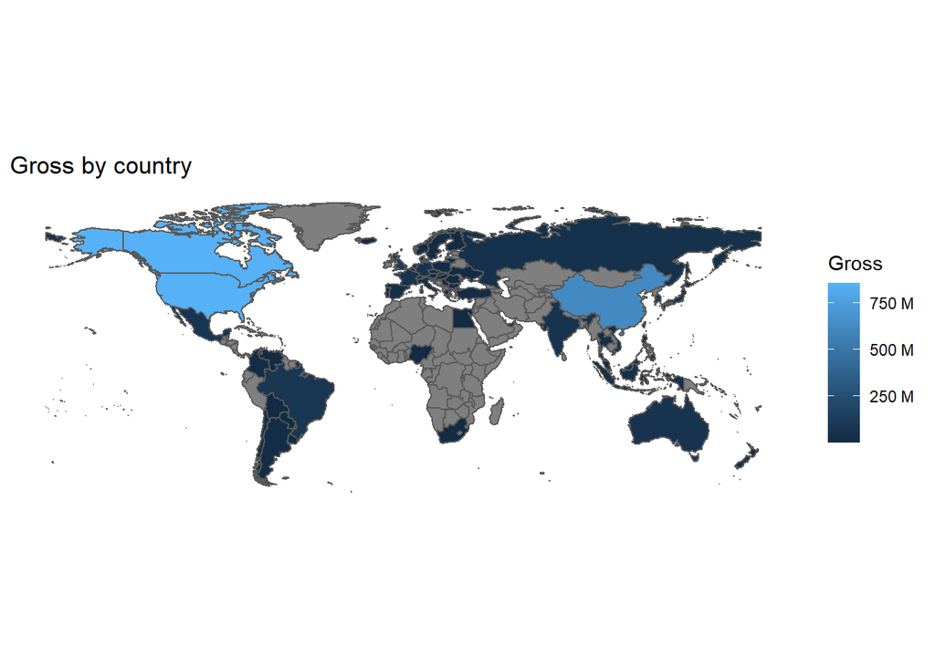

```r
# Create heat map of profits

ggplot() +
 geom_sf(data = world_joined, aes(fill = Gross))+
 ggtitle("Gross by country") +
 theme(axis.text.x = element_blank(),
        axis.text.y = element_blank(),
        axis.ticks = element_blank(),
        rect = element_blank())+
 scale_fill_continuous(name = "Gross", breaks = seq(0, 1000000000, by = 250000000),
 labels = c(0,"250 M", "500 M", "750 M", "1 B"))
```

Generating a heat map based on box office performance again highlights the dominance of North America and China, it also allows us to see at a glance the countries that were included and excluded from the data.

$$\\[0.5in]$$

Our data not only contains the gross box office by country but also the money made over the film’s opening weekend. Studios and critics will often emphasize the importance of a strong opening weekend as it is a good indication of how well the movie will perform over its run.

We will visualise how the opening performance of the film compares to it’s overall box office.

```r
# Create dataset using pivot_longer

endgame_2 <- endgame_1 %>%
  select(Market, Opening, Gross) %>%
  mutate("Remaining" = Gross - Opening ) %>%
  pivot_longer(cols = c("Opening", "Remaining"), names_to = "Box_Office", values_to = "Amount") %>%
  na.omit() # Revove Hong Kong and Korea where opening is unavailable


# Observe data

 endgame_2
```

| Market | Gross | Box_Office | Amount |
| --- | --- | --- | --- |
| United States & Canada | 858373000 | Opening | 357115007 |
| United States & Canada | 858373000 | Remaining | 501257993 |
| China | 629100298 | Opening | 175961330 |
| China | 629100298 | Remaining | 453138968 |
| United Kingdom | 115000524 | Opening | 55981204 |
| United Kingdom | 115000524 | Remaining | 59019320 |
| Brazil | 85672282 | Opening | 26363627 |
| Brazil | 85672282 | Remaining | 59308655 |
| Mexico | 77594943 | Opening | 31905293 |
| Mexico | 77594943 | Remaining | 45689650 |

[output cut: 26 more lines]

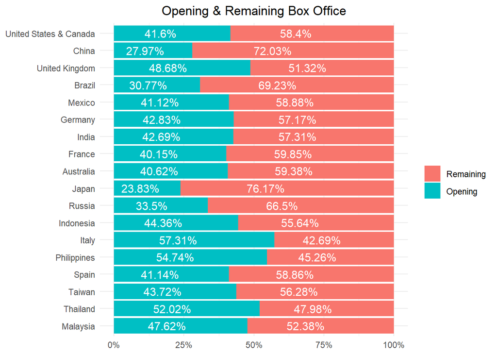

```r
# Create plot

ggplot(endgame_2, aes(x = reorder(Market, Gross), y = Amount, fill = forcats::fct_rev(Box_Office)))+ #forcats::fct_rev places "Opening" at the left
  geom_bar(position = "fill", stat = "identity")+
  ggtitle("Opening & Remaining Box Office")+
  scale_y_continuous(labels = scales::percent)+
  theme_minimal()+
  labs(x = NULL)+
  geom_text(aes(label = paste0(round((Amount/Gross)*100,2),"%")),
                size = 4,
                position = position_fill(vjust = 0.4),
                col = "white")+
  coord_flip()+
  theme(plot.title = element_text(hjust = 0.5),
        axis.title.y = element_blank(),
        axis.title.x = element_blank(),
        legend.title = element_blank())
```

$$\\[0.2in]$$

Interestingly, a significant proportion of the overall box office appears to come from the opening weekend alone.

In the case of the United States, 41.6% of the earnings were obtained in this short time period. In the UK, the third highest performing country, Endgame brought in just under 49% of it’s gross over the opening.

The film was screened in cinemas in North America from April 26th to September 12th (140 days), meaning it brought in 41.6% of it’s money only 2.14% (three days) of the way into it’s total run.

Even the lowest opening percentage - Japan, still accounts for almost a quarter(23.83%) of the total box office. As such, this plot helps underline the importance of a solid opening for a blockbuster movie.

Note that Korea and Hong Kong have been omitted here as the data for their opening weekend box office was unavailable

$$\\[1.5in]$$